# Reproducible Research: Peer Assessment 1

## Loading and preprocessing the data

```r
activity = read.csv("../repdata-data-activity/activity.csv")
```

## What is mean total number of steps taken per day?

1 .Ignoring the missing vales we attempt to calculate the total number of steps taken per day.

```r
tot_steps_per_day <- aggregate(activity$steps, list(activity$date),
                                   sum, na.rm=TRUE)
```

2. Here is the histogram for the total number of steps taken each day.

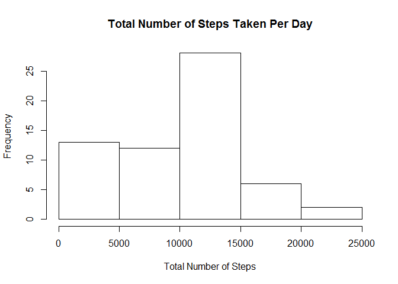

```r
hist(tot_steps_per_day[,2], main='Total Number of Steps Taken Per Day',
     xlab='Total Number of Steps')
```

3. The code used for calculating the median and mean of the total number of steps taken per day.

```r
mean_steps_per_day = mean(tot_steps_per_day[,2])
median_steps_per_day = median(tot_steps_per_day[,2])
```

The calculated mean is 9354.2295082.  
The calculated median is 10395.

## What is the average daily activity pattern?

1. The time series plot depicting the average of steps for each 5-minute interval.  
   The data was aggregated before plotting.

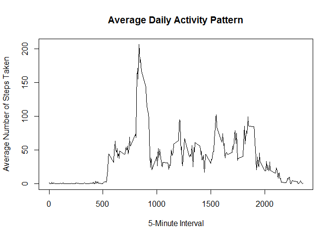

```r
mean_steps_per_day <- aggregate(activity$steps, list(activity$interval),
                                mean, na.rm=TRUE)
plot(mean_steps_per_day[,1], mean_steps_per_day[,2], type="l",
     main='Average Daily Activity Pattern', xlab='5-Minute Interval',
     ylab='Average Number of Steps Taken')
```

2. The code for finding the 5-minute interval with the maximum number of steps.

```r
max_avg_steps <- max(mean_steps_per_day[,2])
max_interval <- mean_steps_per_day[mean_steps_per_day[,2] == max_avg_steps, 1]
```

The 5-minute interval with the maximum number of steps is 835.

## Imputing missing values

```r
num_miss_val <- length(is.na(activity$steps))
```

2. To fill in the missing values, I used the mean for that 5-minute interval.

```r
# The first step was to find the indices with NA values
col_with_na <- activity[which(is.na(activity$steps)),]

# I then joined together the data with NA values with the data found earlier
# (mean_steps_per_day) into a temporary dataframe(temp_df). From there, a new
# dataframe was created(filled_na_df) with the new column; leaving out the column
# with NA values.
temp_df <- merge(x=col_with_na, y=mean_steps_per_day,
                  by.x="interval", by.y="Group.1", all.x=TRUE)
filled_na_df <- data.frame(temp_df$x, temp_df$date, temp_df$interval)
colnames(filled_na_df) <- c('steps', 'date', 'interval')

# To be able to combine the new data, I created another df(filled_values_Df)
# containing only the columns with values from the original dataset.
filled_values_df <- na.omit(activity)

# The two new dataframes are then combined, re-ordered, and re-indexed.
new_activity_df <- rbind(filled_values_df, filled_na_df)
new_activity_df <- new_activity_df[order(new_activity_df$date,
                                         new_activity_df$interval),]
rownames(new_activity_df) <- 1:nrow(new_activity_df)
```

3. Here is the histogram containing the total number of steps taken each day.

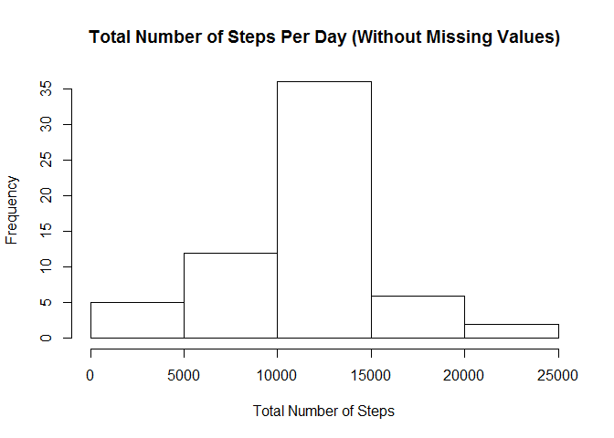

```r
total_steps <- aggregate(new_activity_df$steps, list(new_activity_df$date),
                         sum)
hist(total_steps[,2], main='Total Number of Steps Per Day (Without Missing Values)',
     xlab='Total Number of Steps')
```

4. Code for calculating mean and median.

```r
mean_tot_steps_per_day = mean(total_steps[,2])
median_tot_steps_per_day = median(total_steps[,2])
```

## Are there differences in activity patterns between weekdays and weekends?

1. The process for creating the new column indicating whether it is a weekday or a weekend.

```r
# The first thing to change is make the date into a datetime object. Then change
# those dates into the converted day name(Monday, Tuesday, Wednesday, etc.)
activity$date <- strptime(activity$date, "%Y-%m-%d")
activity$day <- weekdays(activity$date)

# To be able to change the names, I created a function that finds the weekend names
# and changes the label depending on whether it is weekday or weekend.
findWeekend <- function(dayOfWeek) {
  weekend <- c('Saturday', 'Sunday')
  if (dayOfWeek %in% weekend){
    return('weekend')
  } else {
    return('weekday')
  }
}

# This is the applied to the column and all names are changed.
activity$day <- lapply(activity$day, findWeekend)
```

2. Panel plots containing time series plots.

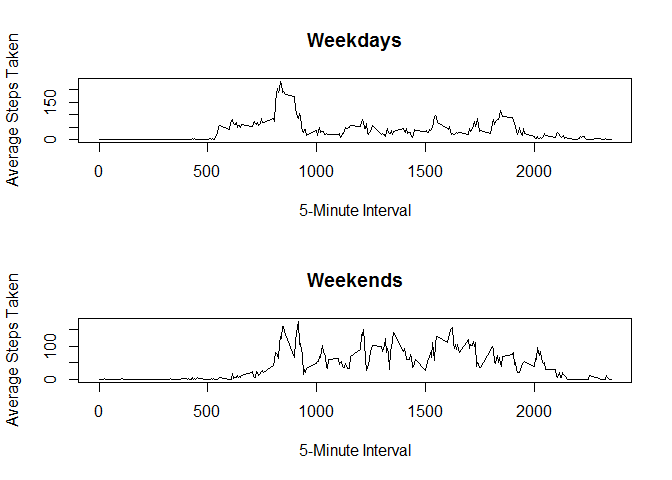

```r
# Break into subsets for weekend and weekdays
weekday_sub <- subset(activity, day == 'weekday')
weekend_sub <- subset(activity, day == 'weekend')

# Aggregate data
mean_steps_weekday <- aggregate(weekday_sub$steps, list(weekday_sub$interval),
                                mean, na.rm=TRUE)
mean_steps_weekend <- aggregate(weekend_sub$steps, list(weekend_sub$interval),
                                mean, na.rm=TRUE)

# Plot panel plots
par(mfrow=c(2,1))
plot(mean_steps_weekday[,1], mean_steps_weekday[,2], type="l", main='Weekdays',
     xlab='5-Minute Interval', ylab='Average Steps Taken')
plot(mean_steps_weekend[,1], mean_steps_weekend[,2], type="l", main='Weekends',
     xlab='5-Minute Interval', ylab='Average Steps Taken')
```